# R Notebook - Linear Time Series TP1 - Deuxième jeu de données

```r
rm(list = ls())
library("ggplot2")
library("zoo")
```

### Question 1

```r
donnees2 = read.csv(file = "./Donnees/Donnees2.csv" )

xm_source = zoo(donnees2)

n = length(donnees2$XM) - 4
xm = zoo(xm_source[1:n])
```

### Question 2

Faire d’abord une régression polynomiale pour vérifier que le coefficient de la pente est significatif.

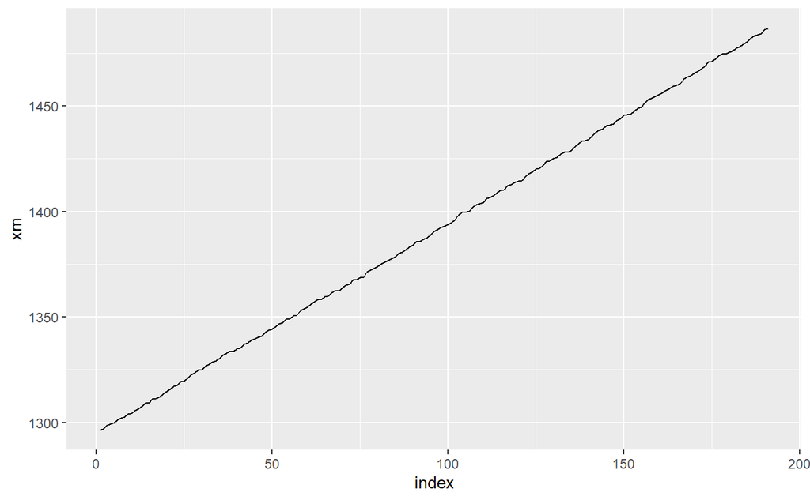

```r
#plot(xm_source) # graphique basique

# Graphique mieux avec ggplot2
index = 1:n
df_display = as.data.frame(cbind(index, xm))
p = ggplot(data = df_display)+geom_line(aes(x = index, y=xm))
p
```

On observe une tendance déterministe. Pour rendre la série stationnaire, faisons alors une première différentiation.

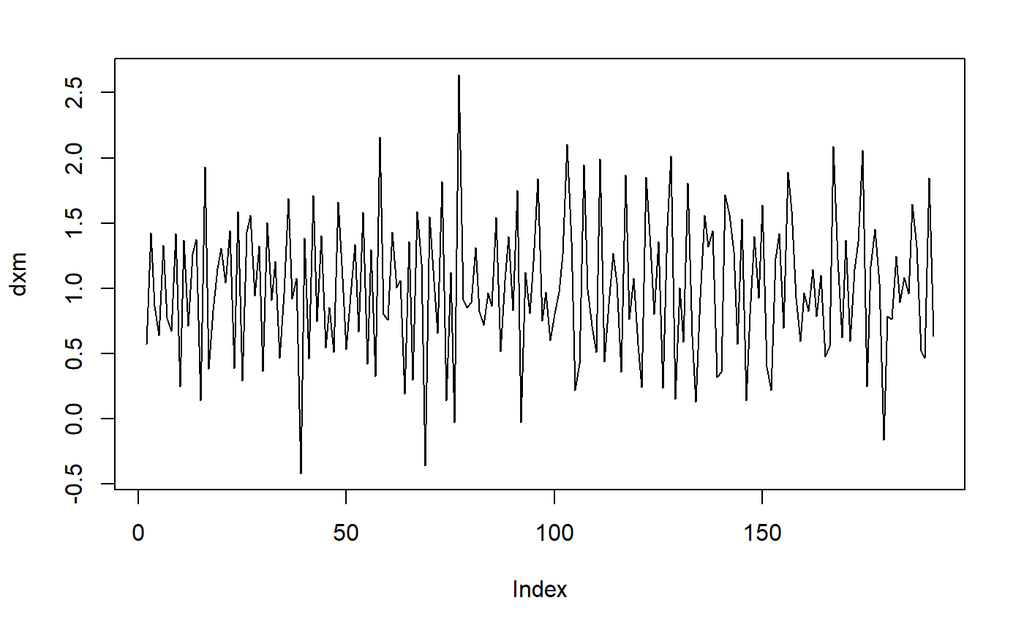

```r
dxm = diff(xm)
plot(dxm)
```

La série semble stationnaire mais n’est pas centrée. Faisont une seconde différentiation pour résoudre ce problème.

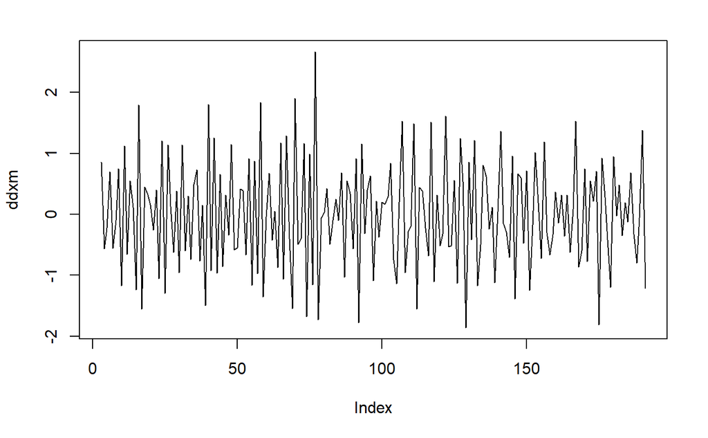

```r
ddxm = diff(dxm)
plot(ddxm)
```

```r
mean(dxm)
```

```
[1] 1.001736
```

```r
mean(ddxm)
```

```
[1] 0.0003496455
```

La séries semble maintenant stationnaire et centrée. Dès lors, on peut essayer d’ajuster un modèle ARMA sur cette transformation de la série originelle.

### Question 3 - auto-corrélogramme

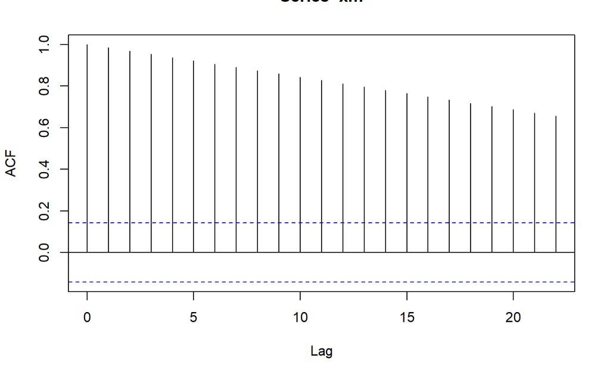

```r
acf(xm)
```

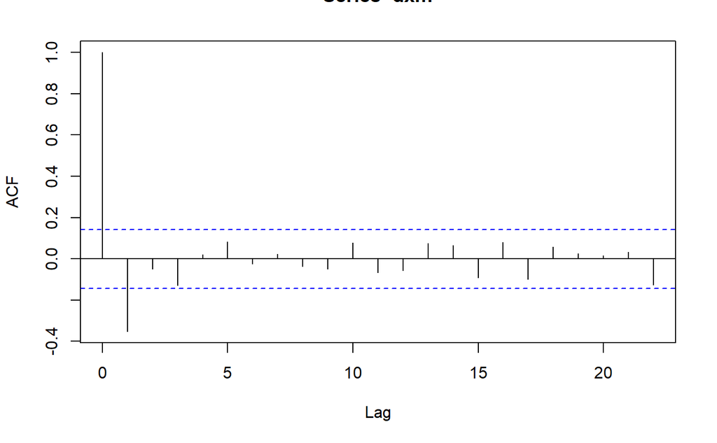

```r
acf(dxm)
```

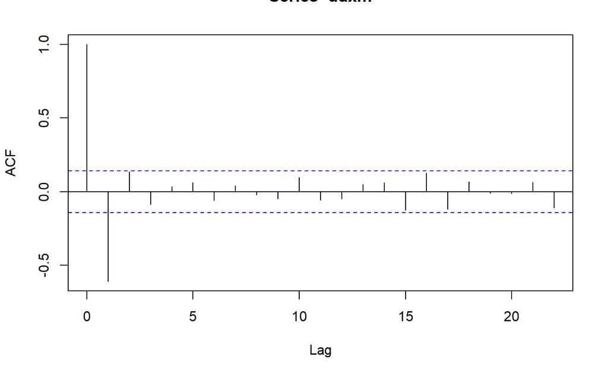

```r
acf(ddxm)
```

Le ACF de ddxm est rassurant : la décroissance des autocorrélations semble exponentielle et donc cela laisse penser à une série centrée stationnaire.

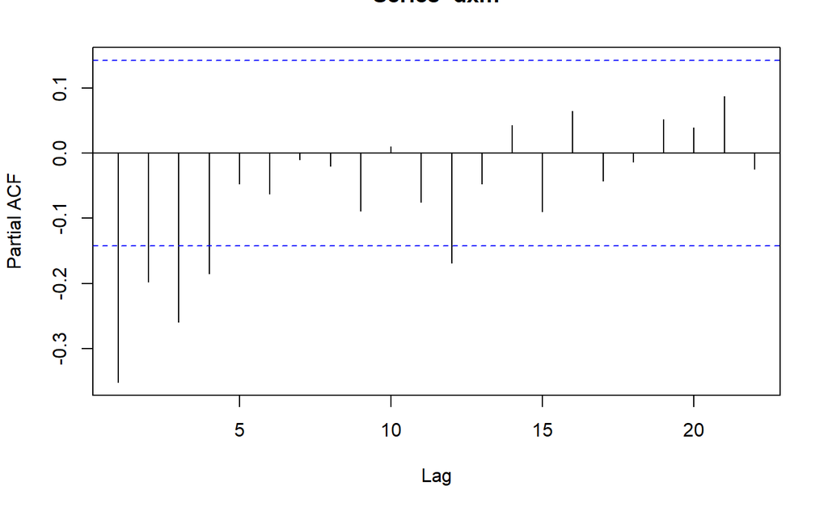

```r
pacf(dxm)
```

### Question 4

```r
#install.packages("bootUR")
library("bootUR")
adf_dxm = adf(dxm)
print(adf_dxm)
```

```
    Two-step ADF test (with intercept) on a single time series

data: dxm
null hypothesis: Series has a unit root
alternative hypothesis: Series is stationary

    estimate largest root statistic  p-value
dxm               -0.3522    -19.87 3.29e-23
```

```r
adf_dxm$null.value
```

```
gamma
    0
```

On rejette à tous les niveaux usuels l’existence d’une racine unité pour cette série. Cela confirme donc ce que nous observions avant.

### Question 5 - ajustement d’un ARMA

En accord avec la question 3 et l’acf et pacf sur dxm, on prend les ordres maximaux $p^*=7$ et $q=1$.

```r
arima701 = arima(dxm - mean(dxm), c(7,0,1))
print(arima701)
```

```
Call:
arima(x = dxm - mean(dxm), order = c(7, 0, 1))

Coefficients:
         ar1     ar2      ar3     ar4     ar5      ar6      ar7      ma1  intercept
      0.3515  0.0796  -0.0550  0.0855  0.1072  -0.0249  -0.0026  -0.9027     0.0020
s.e.  0.1093  0.0888   0.0854  0.0865  0.0817   0.0793   0.0776   0.0819     0.0074

sigma^2 estimated as 0.2126:  log likelihood = -122.88,  aic = 265.76
```

```r
Box.test(arima701$residuals,lag = 9, fitdf = 8,type="Ljung-Box")
```

```
    Box-Ljung test

data:  arima701$residuals
X-squared = 1.7969, df = 1, p-value = 0.1801
```

On ne rejette pas à 10% la nullité jointe des autocorrélations jusqu’à l’ordre 9. Ainsi, le modèle semble assez riche.

### Question 6

Les sous-modèles possibles sont :

- ARMA(6,1)
- ARMA(5,1)
- ARMA(4,1)
- ARMA(3,1)
- ARMA(2,1)
- ARMA(1,1)
- ARMA(0,1)
- ARMA(7,0)
- ARMA(6,0)
- ARMA(5,0)
- ARMA(4,0)
- ARMA(3,0)
- ARMA(2,0)
- ARMA(1,0)
- ARMA(0,0)

#### Test de ARMA701 contre ARMA601

```r
p_val_t_test = function(coef,se){
  t = coef/ se # statistique de Student
  pval = (1-pnorm(abs(t)))*2
  return(pval)
}
```

```r
num_coef = 7
coef = arima701$coef[num_coef]
se = arima701$var.coef[num_coef,num_coef]

p_val_t_test(coef,se)
```

```
      ar7
0.6656049
```

On ne peut donc pas rejeter (à tous les niveaux usuels) que le coefficient phi_7 de lu modèle ARMA(7,1) soit significatif.

### Test de ARMA61 contre ARMA51

```r
# on veut donc tester la significativité de phi_6 dans ARMA61
num_coef = 6

model = arima(dxm-mean(dxm),c(6,0,1))
p_val_t_test(model$coef[num_coef],model$var.coef[num_coef,num_coef])
```

```
         ar6
1.739964e-05
```

On conserve donc le modèle ARMA61, le modèle n’est pas trop complexe pour l’ordre en p.

### Test de ARMA61 contre ARMA60

```r
num_coef = 7

model = arima(dxm-mean(dxm),c(6,0,1))
p_val_t_test(model$coef[num_coef],model$var.coef[num_coef,num_coef])
```

```
ma1
  0
```

On rejette donc à tous les niveaux usuels H_0, c’est-à-dire que psi_1 est nul. Le modèle est donc valide !

### Test ARMA71 contre ARMA70

```r
num_coef = 8
model = arima(dxm-mean(dxm),c(7,0,1))
p_val_t_test(model$coef[num_coef],model$var.coef[num_coef,num_coef])
```

```
ma1
  0
```

### Question 7

Correction : ar2ma1 qui est le bon

Avec ce que j’ai fait, je n’ai qu’un modèle : le ARIMA601.

```r
ar6ma1 = arima(dxm-mean(dxm),c(6,0,1))
ar7ma1 = arima(dxm-mean(dxm),c(7,0,1))

models = c("ar6ma1","ar7ma1")

preds = zoo(matrix(NA,ncol=2,nrow=4),order.by=tail(index(xm_source),4)) # création d'un tableau de prédictions
colnames(preds) <- models
dxm_p <- preds
xmp <- preds

# revoir à partir de là
for (m in models){
  pred1 <- mean(dxm) + zoo(predict(get(m),4)$pred) #, order.by=tail(index(xm.source),4))
  pred2 <- as.numeric(tail(xm,4)) + pred1
  dxm_p[,m] <- pred1
  xmp[,m] <- pred2
}

obs <- tail(xm_source,4) #on stocke les valeurs observées
cbind(obs,xmp) #on les ajoute dans xmp
```

```
          XM   ar6ma1   ar7ma1
192 1487.089 1484.914 1484.915
193 1488.794 1485.121 1485.120
194 1489.422 1487.114 1487.112
195 1490.899 1487.799 1487.799
```

```r
apply(xmp,2, function(x) sqrt(sum((x-obs)^2)/4)/sd(xm_source)) #calcul des RMSE
```

```
    ar6ma1     ar7ma1
0.05080295 0.05080709
```

Le arma61 a la plus faible RMSE, mais est-ce significatif… (Il faudrait réaliser une test de Diebolt-Mariano).

```r
#votre_pol = polynomial()
#racines = solve()
#mod(racines)
polyroot(c(1,-1.22,0.25))
```

```
[1] 1.042288+0i 3.837712+0i
```